# Raw EDC data to ADaM dataset pipeline

cdisc

raw data

clinical trial pipeline

pharmaverse

Authors

Affiliation

[Henrik Vitus Bering Laursen](https://github.com/Henkevitus)

[Seeking new opportunities](https://www.linkedin.com/in/henrikvitusberinglaursen/)

Henrik Vitus Bering Laursen

Published

## 1 Purpose

I wanted to try out the pharmaverse packages to get some hands-on experience with working with the different datasets available in the [`pharmaverse`](https://pharmaverse.org/) packages.

Because I:

- Want a job within working with clinical trial data
- Like working with transforming raw data to analysis-ready datasets
- Like working in R
- Am curious about how much of my health registry skills and intuition transfers to the pharmaceutical clinical trial data pipeline

## 2 Setup

### 2.1 Packages

Now, it would be foolish to not use AI to aid, so I have asked Claude to make a guide on how to work with this CDISC pipeline.

It provided a 9 page document that I am using for support in terms of the overall structure. It is better than starting blind, but probably not as good as reaching out to people working with it.

I expect much of it to be useful, but I know that some won’t be, and leaning on it completely will not teach me anything.

The packages it suggests I use are below:

```r
# Install the packages
#install.packages(c(
#  "sdtm.oak", # raw EDC to SDTM
#  "admiral", # SDTM to ADaM
#  "pharmaverseraw", # raw EDC test data
#  "pharmaversesdtm", # SDTM test data
#  "pharmaverseadam", # ADaM test data
#  "metacore", # specification objects - in case i want to expand on it later
#  "metatools", # validation against specification - in case i want to expand on it later
#  "xportr", # submission-format export - in case i want to expand on it later
#  "dplyr",
#  "tibble",
#  "haven",
#  "labelled"
#))

# Load packages I will defintely use

library(dplyr)
library(haven)
library(tibble)
library(labelled)
library(ggplot2)
```

I am of the habit to just load the entire `tidyverse` package, but I will just load what is necessary, as the 10+ packages of `tidyverse` may not be. Must also practice avoiding unessary redundancies.

## 3 The Data

### 3.1 Raw Data

Before I do anything else, I REALLY want to see what the raw data looks like.

```r
# Load library of raw data
library(pharmaverseraw)

# Datasets available
head(ae_raw) #adverse events
```

```
# A tibble: 6 × 32
  STUDY   PATNUM FOLDER FOLDERL IT.AETERM AEOUTCOME AELLT AELLTCD AEDECOD AEPTCD
  <chr>   <chr>  <chr>  <chr>   <chr>     <chr>     <chr>   <dbl> <chr>    <dbl>
1 CDISCP… 701-1… AE     Advers… Applicat… Not Reco… APPL…  1.00e7 APPLIC…     NA
2 CDISCP… 701-1… AE     Advers… Applicat… Not Reco… APPL…  1.00e7 APPLIC…     NA
3 CDISCP… 701-1… AE     Advers… Diarrhoea Recovere… DIAR…  1.00e7 DIARRH…     NA
4 CDISCP… 701-1… AE     Advers… Atrioven… Not Reco… AV B…  1.00e7 ATRIOV…     NA
5 CDISCP… 701-1… AE     Advers… Erythema  Not Reco… ERYT…  1.00e7 ERYTHE…     NA
6 CDISCP… 701-1… AE     Advers… Erythema  Not Reco… LOCA…  1.00e7 ERYTHE…     NA
# ℹ 22 more variables: AEHLT <chr>, AEHLTCD <dbl>, AEHLGT <chr>,
#   AEHLGTCD <dbl>, AEBODSYS <chr>, AEBDSYCD <dbl>, AESOC <chr>, AESOCCD <dbl>,
#   IT.AESEV <chr>, IT.AESER <chr>, IT.AEREL <chr>, IT.AEACN <chr>,
#   AESCAN <chr>, AESCNO <chr>, AEDIS <chr>, IT.AESDTH <chr>, IT.AESHOSP <chr>,
#   IT.AESLIFE <chr>, AESOD <chr>, AEDTCOL <chr>, IT.AESTDAT <chr>,
#   IT.AEENDAT <chr>
```

```r
head(dm_raw) #demographics
```

```
# A tibble: 6 × 13
  STUDY PATNUM IT.AGE IT.SEX IT.ETHNIC IT.RACE COUNTRY PLANNED_ARM PLANNED_ARMCD
  <chr> <chr>   <dbl> <chr>  <chr>     <chr>   <chr>   <chr>       <chr>
1 CDIS… 701-1…     63 Female Hispanic… White   USA     Placebo     Pbo
2 CDIS… 701-1…     64 Male   Hispanic… White   USA     Placebo     Pbo
3 CDIS… 701-1…     71 Male   Not Hisp… White   USA     Xan High    Xan_Hi
4 CDIS… 701-1…     74 Male   Not Hisp… White   USA     Xan Low     Xan_Lo
5 CDIS… 701-1…     77 Female Not Hisp… White   USA     Xan High    Xan_Hi
6 CDIS… 701-1…     85 Female Not Hisp… White   USA     Placebo     Pbo
# ℹ 4 more variables: ACTUAL_ARM <chr>, ACTUAL_ARMCD <chr>, COL_DT <chr>,
#   IC_DT <chr>
```

```r
head(ec_raw) #exposure as collected
```

```
# A tibble: 6 × 14
  STUDY  PATNUM VISITNAME FOLDER FOLDERL IT.ECREFID DRUGAD IT.ECSTDAT IT.ECENDAT
  <chr>  <chr>  <chr>     <chr>  <chr>   <chr>      <chr>  <chr>      <chr>
1 CDISC… 701-1… Baseline  EC     Exposu… 123        PLACE… 02-Jan-20… 16-Jan-20…
2 CDISC… 701-1… Week 2    EC     Exposu… 123        PLACE… 17-Jan-20… 18-Jun-20…
3 CDISC… 701-1… Week 24   EC     Exposu… 123        PLACE… 19-Jun-20… 02-Jul-20…
4 CDISC… 701-1… Baseline  EC     Exposu… 123        PLACE… 05-Aug-20… 27-Aug-20…
5 CDISC… 701-1… Week 2    EC     Exposu… 123        PLACE… 28-Aug-20… 01-Sep-20…
6 CDISC… 701-1… Baseline  EC     Exposu… 123        XANOM… 19-Jul-20… 01-Aug-20…
# ℹ 5 more variables: IT.ECDSTXT <dbl>, IT.ECDOSU <chr>, DOSFM <chr>,
#   DOSFRQ <chr>, IT.ECROUTE <chr>
```

```r
#head(ds_raw) #subject disposition
#head(vs_raw) #vital signs
```

List of datasets were found by trail: https://pharmaverse.github.io/pharmaverseraw/ -> https://github.com/pharmaverse/pharmaverseraw/tree/main/data.

Info about them can be found via typing `?pharmaverse::[insert name of dataset]` in the console.

At first glance:

- This is VERY similar to health registry data
- Relatively intuitive variable names

I really like to know some basic stuff about datasets that is usually not capture in the functions that I use frequently. I want to make a function that quickly gives me an overview of counts of rows, columns, and whether dataset is multiple patients per row or not.

```r
#| label: data-raw-inspect
#| echo: true
#| output: true

inspect_basic <- function(data, id_var = "PATNUM") {
  d <- dim(data)
  cat(d[1], "rows,", d[2], "columns\n")

  if (id_var %in% names(data)) {
    n_pat <- length(unique(data[[id_var]]))
    if (d[1] > n_pat) {
      # if more rows than unique patient IDs
      cat("MULTIPLE rows per patient (", n_pat, "patients )\n")
    } else {
      cat("One row per patient (", n_pat, "patients )\n")
    }
  } else {
    cat(id_var, "not found in this dataset\n")
  }
}

inspect_basic(ae_raw)
```

```
1191 rows, 32 columns
MULTIPLE rows per patient ( 225 patients )
```

```r
inspect_basic(dm_raw)
```

```
306 rows, 13 columns
One row per patient ( 306 patients )
```

As suspected, adverse events are multiple rows while demographics are single rows per patient. It’s the same in health registry data.

### 3.2 Study Data Tabulation Model (SDTM) Data

SDTM data is raw data transformed into the SDTM model. As far as I understand, that means basically means taking the data from sites and making them fit in prespecified boxes according to the SDTM model paper and SDTM implementation guide.

Part of that is making all the data fit into a limited set of domains.

Let’s look at some SDTM data from the `pharmaversesdtm` package with the better method of writing `help(package = "pharmaversesdtm")` in the console. I see that this package has a lot of datasets, so let’s load individual ones instead of the entire library, and stay in my wheel-house: the metabolic datasets.

```r
# Load from library
dm_metabolic <- pharmaversesdtm::dm_metabolic
vs_metabolic <- pharmaversesdtm::vs_metabolic
qs_metabolic <- pharmaversesdtm::qs_metabolic
lb_metabolic <- pharmaversesdtm::lb_metabolic

# looking at the datasets
glimpse(dm_metabolic)
```

```
Rows: 5
Columns: 28
$ STUDYID  <chr> "CDISCPILOT01", "CDISCPILOT01", "CDISCPILOT01", "CDISCPILOT01…
$ DOMAIN   <chr> "DM", "DM", "DM", "DM", "DM"
$ USUBJID  <chr> "01-701-1015", "01-701-1023", "01-701-1028", "01-701-1033", "…
$ SUBJID   <chr> "1015", "1023", "1028", "1033", "1034"
$ RFSTDTC  <chr> "2014-01-02", "2012-08-05", "2013-07-19", "2014-03-18", "2014…
$ RFENDTC  <chr> "2014-07-02", "2012-09-02", "2014-01-14", "2014-04-14", "2014…
$ RFXSTDTC <chr> "2014-01-02", "2012-08-05", "2013-07-19", "2014-03-18", "2014…
$ RFXENDTC <chr> "2014-07-02", "2012-09-01", "2014-01-14", "2014-03-31", "2014…
$ RFICDTC  <chr> NA, NA, NA, NA, NA
$ RFPENDTC <chr> "2014-07-02T11:45", "2013-02-18", "2014-01-14T11:10", "2014-0…
$ DTHDTC   <chr> NA, NA, NA, NA, NA
$ DTHFL    <chr> NA, NA, NA, NA, NA
$ SITEID   <chr> "701", "701", "701", "701", "701"
$ BRTHDTC  <chr> "1950-12-26", "1948-07-22", "1942-07-11", "1940-03-10", "1937…
$ AGE      <dbl> 63, 64, 71, 74, 77
$ AGEU     <chr> "YEARS", "YEARS", "YEARS", "YEARS", "YEARS"
$ SEX      <chr> "F", "M", "M", "M", "F"
$ RACE     <chr> "WHITE", "WHITE", "WHITE", "WHITE", "WHITE"
$ ETHNIC   <chr> "HISPANIC OR LATINO", "HISPANIC OR LATINO", "NOT HISPANIC OR …
$ ARMCD    <chr> "Pbo", "Pbo", "Ins", "Ins", "Ins"
$ ARM      <chr> "Placebo", "Placebo", "Insulin", "Insulin", "Insulin"
$ ACTARMCD <chr> "Pbo", "Pbo", "Ins", "Ins", "Ins"
$ ACTARM   <chr> "Placebo", "Placebo", "Insulin", "Insulin", "Insulin"
$ COUNTRY  <chr> "USA", "USA", "USA", "USA", "USA"
$ DMDTC    <chr> "2013-12-26", "2012-07-22", "2013-07-11", "2014-03-10", "2014…
$ DMDY     <dbl> -7, -14, -8, -8, -7
$ ARMNRS   <chr> NA, NA, NA, NA, NA
$ ACTARMUD <chr> NA, NA, NA, NA, NA
```

```r
head(dm_metabolic)
```

```
# A tibble: 5 × 28
  STUDYID      DOMAIN USUBJID   SUBJID RFSTDTC RFENDTC RFXSTDTC RFXENDTC RFICDTC
  <chr>        <chr>  <chr>     <chr>  <chr>   <chr>   <chr>    <chr>    <chr>
1 CDISCPILOT01 DM     01-701-1… 1015   2014-0… 2014-0… 2014-01… 2014-07… <NA>
2 CDISCPILOT01 DM     01-701-1… 1023   2012-0… 2012-0… 2012-08… 2012-09… <NA>
3 CDISCPILOT01 DM     01-701-1… 1028   2013-0… 2014-0… 2013-07… 2014-01… <NA>
4 CDISCPILOT01 DM     01-701-1… 1033   2014-0… 2014-0… 2014-03… 2014-03… <NA>
5 CDISCPILOT01 DM     01-701-1… 1034   2014-0… 2014-1… 2014-07… 2014-12… <NA>
# ℹ 19 more variables: RFPENDTC <chr>, DTHDTC <chr>, DTHFL <chr>, SITEID <chr>,
#   BRTHDTC <chr>, AGE <dbl>, AGEU <chr>, SEX <chr>, RACE <chr>, ETHNIC <chr>,
#   ARMCD <chr>, ARM <chr>, ACTARMCD <chr>, ACTARM <chr>, COUNTRY <chr>,
#   DMDTC <chr>, DMDY <dbl>, ARMNRS <chr>, ACTARMUD <chr>
```

```r
glimpse(vs_metabolic)
```

```
Rows: 719
Columns: 24
$ STUDYID  <chr> "CDISCPILOT01", "CDISCPILOT01", "CDISCPILOT01", "CDISCPILOT01…
$ DOMAIN   <chr> "VS", "VS", "VS", "VS", "VS", "VS", "VS", "VS", "VS", "VS", "…
$ USUBJID  <chr> "01-701-1015", "01-701-1015", "01-701-1015", "01-701-1015", "…
$ VSSEQ    <int> 1, 2, 3, 4, 5, 6, 7, 8, 9, 10, 11, 12, 13, 14, 15, 16, 17, 18…
$ VSTESTCD <chr> "BMI", "BMI", "BMI", "BMI", "BMI", "BMI", "BMI", "BMI", "BMI"…
$ VSTEST   <chr> "Body Mass Index", "Body Mass Index", "Body Mass Index", "Bod…
$ VSPOS    <chr> NA, NA, NA, NA, NA, NA, NA, NA, NA, NA, NA, "SUPINE", "STANDI…
$ VSORRES  <chr> "38.1050023495237", "38.0622837370242", "38.5321884745183", "…
$ VSORRESU <chr> "kg/m2", "kg/m2", "kg/m2", "kg/m2", "kg/m2", "kg/m2", "kg/m2"…
$ VSSTRESC <chr> "38.1050023495237", "38.0622837370242", "38.5321884745183", "…
$ VSSTRESN <dbl> 38.10500, 38.06228, 38.53219, 38.62617, 38.67743, 38.79277, 3…
$ VSSTRESU <chr> "kg/m2", "kg/m2", "kg/m2", "kg/m2", "kg/m2", "kg/m2", "kg/m2"…
$ VSSTAT   <chr> NA, NA, NA, NA, NA, NA, NA, NA, NA, NA, NA, NA, NA, NA, NA, N…
$ VSLOC    <chr> NA, NA, NA, NA, NA, NA, NA, NA, NA, NA, NA, NA, NA, NA, NA, N…
$ VSBLFL   <chr> NA, "Y", NA, NA, NA, NA, NA, NA, NA, NA, NA, NA, NA, NA, NA, …
$ VISITNUM <dbl> 1.0, 3.0, 4.0, 5.0, 7.0, 8.0, 9.0, 10.0, 11.0, 12.0, 13.0, 1.…
$ VISIT    <chr> "SCREENING 1", "BASELINE", "WEEK 2", "WEEK 4", "WEEK 6", "WEE…
$ VISITDY  <dbl> -7, 1, 14, 28, 42, 56, 84, 112, 140, 168, 182, -7, -7, -7, -1…
$ VSDTC    <chr> "2013-12-26", "2014-01-02", "2014-01-16", "2014-01-30", "2014…
$ VSDY     <dbl> -7, 1, 15, 29, 42, 63, 84, 126, 140, 168, 182, -7, -7, -7, -2…
$ VSTPT    <chr> NA, NA, NA, NA, NA, NA, NA, NA, NA, NA, NA, "AFTER LYING DOWN…
$ VSTPTNUM <dbl> NA, NA, NA, NA, NA, NA, NA, NA, NA, NA, NA, 815, 816, 817, 81…
$ VSELTM   <chr> NA, NA, NA, NA, NA, NA, NA, NA, NA, NA, NA, "PT5M", "PT1M", "…
$ VSTPTREF <chr> NA, NA, NA, NA, NA, NA, NA, NA, NA, NA, NA, "PATIENT SUPINE",…
```

```r
head(vs_metabolic)
```

```
# A tibble: 6 × 24
  STUDYID   DOMAIN USUBJID VSSEQ VSTESTCD VSTEST VSPOS VSORRES VSORRESU VSSTRESC
  <chr>     <chr>  <chr>   <int> <chr>    <chr>  <chr> <chr>   <chr>    <chr>
1 CDISCPIL… VS     01-701…     1 BMI      Body … <NA>  38.105… kg/m2    38.1050…
2 CDISCPIL… VS     01-701…     2 BMI      Body … <NA>  38.062… kg/m2    38.0622…
3 CDISCPIL… VS     01-701…     3 BMI      Body … <NA>  38.532… kg/m2    38.5321…
4 CDISCPIL… VS     01-701…     4 BMI      Body … <NA>  38.626… kg/m2    38.6261…
5 CDISCPIL… VS     01-701…     5 BMI      Body … <NA>  38.677… kg/m2    38.6774…
6 CDISCPIL… VS     01-701…     6 BMI      Body … <NA>  38.792… kg/m2    38.7927…
# ℹ 14 more variables: VSSTRESN <dbl>, VSSTRESU <chr>, VSSTAT <chr>,
#   VSLOC <chr>, VSBLFL <chr>, VISITNUM <dbl>, VISIT <chr>, VISITDY <dbl>,
#   VSDTC <chr>, VSDY <dbl>, VSTPT <chr>, VSTPTNUM <dbl>, VSELTM <chr>,
#   VSTPTREF <chr>
```

```r
glimpse(qs_metabolic)
```

```
Rows: 966
Columns: 18
$ STUDYID  <chr> "CDISCPILOT01", "CDISCPILOT01", "CDISCPILOT01", "CDISCPILOT01…
$ USUBJID  <chr> "01-701-1015", "01-701-1015", "01-701-1015", "01-701-1015", "…
$ DOMAIN   <chr> "QS", "QS", "QS", "QS", "QS", "QS", "QS", "QS", "QS", "QS", "…
$ VISIT    <chr> "SCREENING 1", "SCREENING 1", "SCREENING 1", "SCREENING 1", "…
$ VISITNUM <dbl> 1, 1, 1, 1, 1, 1, 1, 1, 1, 1, 1, 1, 1, 1, 1, 1, 1, 1, 1, 1, 1…
$ VISITDY  <dbl> -7, -7, -7, -7, -7, -7, -7, -7, -7, -7, -7, -7, -7, -7, -7, -…
$ QSBLFL   <chr> NA, NA, NA, NA, NA, NA, NA, NA, NA, NA, NA, NA, NA, NA, NA, N…
$ QSDTC    <chr> "2013-12-26", "2013-12-26", "2013-12-26", "2013-12-26", "2013…
$ QSDY     <dbl> -7, -7, -7, -7, -7, -7, -7, -7, -7, -7, -7, -7, -7, -7, -7, -…
$ QSCAT    <chr> "COEQ", "COEQ", "COEQ", "COEQ", "COEQ", "COEQ", "COEQ", "COEQ…
$ QSTEST   <chr> "How hungry have you felt?", "How full have you felt?", "How …
$ QSTESTCD <chr> "COEQ01", "COEQ02", "COEQ03", "COEQ04", "COEQ05", "COEQ06", "…
$ QSORRES  <chr> "17", "81", "38", "33", "60", "60", "12", "29", "58", "63", "…
$ QSORRESU <chr> "mm", "mm", "mm", "mm", "mm", "mm", "mm", "mm", "mm", "mm", "…
$ QSSTRESC <chr> "17", "81", "38", "33", "60", "60", "12", "29", "58", "63", "…
$ QSSTRESN <dbl> 17, 81, 38, 33, 60, 60, 12, 29, 58, 63, 51, 51, 53, 56, 87, 8…
$ QSSTRESU <chr> "mm", "mm", "mm", "mm", "mm", "mm", "mm", "mm", "mm", "mm", "…
$ QSSEQ    <int> 1, 2, 3, 4, 5, 6, 7, 8, 9, 10, 11, 12, 13, 14, 15, 16, 17, 18…
```

```r
head(qs_metabolic)
```

```
# A tibble: 6 × 18
  STUDYID  USUBJID DOMAIN VISIT VISITNUM VISITDY QSBLFL QSDTC  QSDY QSCAT QSTEST
  <chr>    <chr>   <chr>  <chr>    <dbl>   <dbl> <chr>  <chr> <dbl> <chr> <chr>
1 CDISCPI… 01-701… QS     SCRE…        1      -7 <NA>   2013…    -7 COEQ  How h…
2 CDISCPI… 01-701… QS     SCRE…        1      -7 <NA>   2013…    -7 COEQ  How f…
3 CDISCPI… 01-701… QS     SCRE…        1      -7 <NA>   2013…    -7 COEQ  How s…
4 CDISCPI… 01-701… QS     SCRE…        1      -7 <NA>   2013…    -7 COEQ  How s…
5 CDISCPI… 01-701… QS     SCRE…        1      -7 <NA>   2013…    -7 COEQ  How h…
6 CDISCPI… 01-701… QS     SCRE…        1      -7 <NA>   2013…    -7 COEQ  How a…
# ℹ 7 more variables: QSTESTCD <chr>, QSORRES <chr>, QSORRESU <chr>,
#   QSSTRESC <chr>, QSSTRESN <dbl>, QSSTRESU <chr>, QSSEQ <int>
```

```r
glimpse(lb_metabolic)
```

```
Rows: 309
Columns: 24
$ STUDYID  <chr> "CDISCPILOT01", "CDISCPILOT01", "CDISCPILOT01", "CDISCPILOT01…
$ DOMAIN   <chr> "LB", "LB", "LB", "LB", "LB", "LB", "LB", "LB", "LB", "LB", "…
$ USUBJID  <chr> "01-701-1015", "01-701-1023", "01-701-1028", "01-701-1033", "…
$ LBSEQ    <int> 1, 1, 1, 1, 1, 2, 2, 2, 2, 2, 3, 3, 3, 3, 3, 4, 4, 4, 4, 4, 5…
$ LBTESTCD <chr> "ALB", "ALB", "ALB", "ALB", "ALB", "ALP", "ALP", "ALP", "ALP"…
$ LBTEST   <chr> "Albumin", "Albumin", "Albumin", "Albumin", "Albumin", "Alkal…
$ LBCAT    <chr> "CHEMISTRY", "CHEMISTRY", "CHEMISTRY", "CHEMISTRY", "CHEMISTR…
$ LBORRES  <chr> "3.8", "4.0", "4.4", "3.8", "4.3", "34", "98", "44", "67", "4…
$ LBORRESU <chr> "g/dL", "g/dL", "g/dL", "g/dL", "g/dL", "U/L", "U/L", "U/L", …
$ LBORNRLO <chr> "3.3", "3.3", "3.5", "3.5", "3.5", "35", "35", "35", "35", "3…
$ LBORNRHI <chr> "4.9", "4.9", "4.6", "4.6", "4.6", "115", "115", "115", "115"…
$ LBSTRESC <chr> "38", "40", "44", "38", "43", "34", "98", "44", "67", "41", "…
$ LBSTRESN <dbl> 38.00000, 40.00000, 44.00000, 38.00000, 43.00000, 34.00000, 9…
$ LBSTRESU <chr> "g/L", "g/L", "g/L", "g/L", "g/L", "U/L", "U/L", "U/L", "U/L"…
$ LBSTNRLO <dbl> 33.00, 33.00, 35.00, 35.00, 35.00, 35.00, 35.00, 35.00, 35.00…
$ LBSTNRHI <dbl> 49.00, 49.00, 46.00, 46.00, 46.00, 115.00, 115.00, 115.00, 11…
$ LBNRIND  <chr> "NORMAL", "NORMAL", "NORMAL", "NORMAL", "NORMAL", "LOW", "NOR…
$ LBBLFL   <chr> "Y", "Y", "Y", "Y", "Y", "Y", "Y", "Y", "Y", "Y", "Y", "Y", "…
$ LBFAST   <chr> "Y", "Y", "Y", "Y", "Y", "Y", "Y", "Y", "Y", "Y", "Y", "Y", "…
$ VISITNUM <dbl> 1, 1, 1, 1, 1, 1, 1, 1, 1, 1, 1, 1, 1, 1, 1, 1, 1, 1, 1, 1, 1…
$ VISIT    <chr> "SCREENING 1", "SCREENING 1", "SCREENING 1", "SCREENING 1", "…
$ VISITDY  <dbl> -7, -7, -7, -7, -7, -7, -7, -7, -7, -7, -7, -7, -7, -7, -7, -…
$ LBDTC    <chr> "2013-12-26T14:45", "2012-07-22T12:13", "2013-07-11T12:02", "…
$ LBDY     <dbl> -7, -14, -8, -8, -7, -7, -14, -8, -8, -7, -7, -14, -8, -8, -7…
```

```r
head(lb_metabolic)
```

```
# A tibble: 6 × 24
  STUDYID   DOMAIN USUBJID LBSEQ LBTESTCD LBTEST LBCAT LBORRES LBORRESU LBORNRLO
  <chr>     <chr>  <chr>   <int> <chr>    <chr>  <chr> <chr>   <chr>    <chr>
1 CDISCPIL… LB     01-701…     1 ALB      Album… CHEM… 3.8     g/dL     3.3
2 CDISCPIL… LB     01-701…     1 ALB      Album… CHEM… 4.0     g/dL     3.3
3 CDISCPIL… LB     01-701…     1 ALB      Album… CHEM… 4.4     g/dL     3.5
4 CDISCPIL… LB     01-701…     1 ALB      Album… CHEM… 3.8     g/dL     3.5
5 CDISCPIL… LB     01-701…     1 ALB      Album… CHEM… 4.3     g/dL     3.5
6 CDISCPIL… LB     01-701…     2 ALP      Alkal… CHEM… 34      U/L      35
# ℹ 14 more variables: LBORNRHI <chr>, LBSTRESC <chr>, LBSTRESN <dbl>,
#   LBSTRESU <chr>, LBSTNRLO <dbl>, LBSTNRHI <dbl>, LBNRIND <chr>,
#   LBBLFL <chr>, LBFAST <chr>, VISITNUM <dbl>, VISIT <chr>, VISITDY <dbl>,
#   LBDTC <chr>, LBDY <dbl>
```

```r
# Distinct subjects (dm_metabolic shows 5, but just checking another one)
n_distinct(vs_metabolic$USUBJID)
```

```
[1] 5
```

Unless you have an enourmous screen, you’re probably better off using the `View()` function, rather than `head()`. It just translates poorly to a blogpost, so I almost always use `head()`.

Each of the datasets have some variables without any prefix, and then the remaining have a prefix. This prefix corresponds to the domain, which also has its own variable.

I feel like there is a lot of redundancy. Why not just keep the variables without the prefix, and whenever the variables are drawn from the dataset to make the ADaM data, add the prefix in the join?

Is it a leftover from a limitation of using SAS? Or an older version of SAS?

Is it just “How it is”, and slow to change due to the nature of having controlled terminology and fixed models?

Perhaps it is because often one needs to open a SDTM dataset with a certain domain and then quickly isolate the variables with the domain prefix?

### 3.3 ADaM Data

Let’s look at ADaM data. The basic things I know is that ADSL is subject level dataset with one row per person, and most of the information in columns for each patient.

This is very similar to how I made datasets in my registry data research. You can’t have a single dataset with ALL information though, there would be too many empty or missing values.

You would need a Basic Data Structure dataset, which as I understand is: One row per subject per parameter per analysis timepoint.. Or visit.. That probably means that it should be relatively clean with few repetitions and unecessary columns.

```r
adsl <- pharmaverseadam::adsl
advs_metabolic <- pharmaverseadam::advs_metabolic

glimpse(adsl)
```

```
Rows: 306
Columns: 57
$ STUDYID  <chr> "CDISCPILOT01", "CDISCPILOT01", "CDISCPILOT01", "CDISCPILOT01…
$ USUBJID  <chr> "01-701-1015", "01-701-1023", "01-701-1028", "01-701-1033", "…
$ SUBJID   <chr> "1015", "1023", "1028", "1033", "1034", "1047", "1057", "1097…
$ SITEID   <chr> "701", "701", "701", "701", "701", "701", "701", "701", "701"…
$ COUNTRY  <chr> "USA", "USA", "USA", "USA", "USA", "USA", "USA", "USA", "USA"…
$ RFSTDTC  <chr> "2014-01-02", "2012-08-05", "2013-07-19", "2014-03-18", "2014…
$ RFENDTC  <chr> "2014-07-02", "2012-09-02", "2014-01-14", "2014-04-14", "2014…
$ RFXSTDTC <chr> "2014-01-02", "2012-08-05", "2013-07-19", "2014-03-18", "2014…
$ RFXENDTC <chr> "2014-07-02", "2012-09-01", "2014-01-14", "2014-03-31", "2014…
$ RFPENDTC <chr> "2014-07-02T11:45", "2013-02-18", "2014-01-14T11:10", "2014-0…
$ SCRFDT   <date> NA, NA, NA, NA, NA, NA, 2013-12-20, NA, NA, NA, NA, NA, NA, …
$ FRVDT    <date> NA, 2013-02-18, NA, 2014-09-15, NA, 2013-07-28, NA, NA, 2013…
$ DTHDTC   <chr> NA, NA, NA, NA, NA, NA, NA, NA, NA, NA, NA, NA, NA, NA, NA, N…
```

[output cut: 44 more lines]

```r
glimpse(advs_metabolic)
```

```
Rows: 760
Columns: 101
$ STUDYID  <chr> "CDISCPILOT01", "CDISCPILOT01", "CDISCPILOT01", "CDISCPILOT01…
$ USUBJID  <chr> "01-701-1015", "01-701-1015", "01-701-1015", "01-701-1015", "…
$ SUBJID   <chr> "1015", "1015", "1015", "1015", "1015", "1015", "1015", "1015…
$ SITEID   <chr> "701", "701", "701", "701", "701", "701", "701", "701", "701"…
$ COUNTRY  <chr> "USA", "USA", "USA", "USA", "USA", "USA", "USA", "USA", "USA"…
$ DOMAIN   <chr> "VS", "VS", "VS", "VS", "VS", "VS", "VS", "VS", "VS", "VS", "…
$ RFSTDTC  <chr> "2014-01-02", "2014-01-02", "2014-01-02", "2014-01-02", "2014…
$ RFENDTC  <chr> "2014-07-02", "2014-07-02", "2014-07-02", "2014-07-02", "2014…
$ RFXSTDTC <chr> "2014-01-02", "2014-01-02", "2014-01-02", "2014-01-02", "2014…
$ RFXENDTC <chr> "2014-07-02", "2014-07-02", "2014-07-02", "2014-07-02", "2014…
$ RFPENDTC <chr> "2014-07-02T11:45", "2014-07-02T11:45", "2014-07-02T11:45", "…
$ SCRFDT   <date> NA, NA, NA, NA, NA, NA, NA, NA, NA, NA, NA, NA, NA, NA, NA, …
$ FRVDT    <date> NA, NA, NA, NA, NA, NA, NA, NA, NA, NA, NA, NA, NA, NA, NA, …
```

[output cut: 88 more lines]

After viewing the data I must say: **That is A LOT of extra columns and values i.e. redundancies.**

It is as if they want to be able to perform all analyses on any ADaM dataset, since it seems the demographics data from `adsl` is also in the `advs_metabolic` dataset.

## 4 SDTM to ADaM

Now I want to look at what it takes to move from SDTM to ADaM.

Without a statistical analysis plan, a study, a supervisor/manager to give me the overall details and other stuff to about when doing this, I will try to just choose the bare minimum.

I would certainly want to make:

- ADSL (Analysis Dataset Subject Level)
- One BDS (Basic Data Structure) dataset

Staying with the `_metabolic` SDTM datasets. The package I will be using is [`admiral`](https://pharmaverse.github.io/admiral/cran-release/).

First, I check out the documentation for the datasets `dm_metabolic` and `vs_metabolic` by typing `?pharmaversesdtm::[insert dataset]` in console.

I just want the following:

- Basic demographic characteristics in the ADSL
- Changes in Blood Pressure from baseline to last day of treatment

To get there, I need to “derive” data from the SDTM data to make the ADaM datasets. So let us look at the different derive functions, which according to the [`package documentation`](https://pharmaverse.github.io/admiral/cran-release/) is quite modular, so it can be mixed and matched according to needs.

And `help(package = "admiral")` in console provides an overview of which function does what.

### 4.1 ADSL

I want to first try one function, making a variable for the start of the treatment.

```r
library(admiral)

# Let's first test one function
adsl <- dm_metabolic |>
  derive_vars_dt(dtc = RFXSTDTC, new_vars_prefix = "TRTS")

adsl |> select(RFXSTDTC, TRTSDT)
```

```
# A tibble: 5 × 2
  RFXSTDTC   TRTSDT
  <chr>      <date>
1 2014-01-02 2014-01-02
2 2012-08-05 2012-08-05
3 2013-07-19 2013-07-19
4 2014-03-18 2014-03-18
5 2014-07-01 2014-07-01
```

Wonderful. It does what it says it does.

Now let us do some more:

- Start and end date of treatment
- Duration of treatment
- Flag for whether the patient is in the safety or intention-to-treat population
- Age group

```r
adsl <- dm_metabolic |>
  derive_vars_dt(dtc = RFXSTDTC, new_vars_prefix = "TRTS") |>
  derive_vars_dt(dtc = RFXENDTC, new_vars_prefix = "TRTE") |>
  derive_var_trtdurd() |>
  mutate(
    SAFFL = if_else(!is.na(TRTSDT), "Y", "N"),
    ITTFL = if_else(!is.na(ARMCD), "Y", "N"),
    AGEGR1 = case_when(
      AGE < 65 ~ "<65",
      AGE >= 65 ~ "65+",
    )
  ) |>
  select(
    STUDYID, USUBJID, SUBJID, SITEID, AGE, AGEGR1, SEX, RACE, ARM, ACTARM, ARMCD, TRTSDT, TRTEDT, TRTDURD, SAFFL, ITTFL
  )

adsl
```

```
# A tibble: 5 × 16
  STUDYID      USUBJID SUBJID SITEID   AGE AGEGR1 SEX   RACE  ARM   ACTARM ARMCD
  <chr>        <chr>   <chr>  <chr>  <dbl> <chr>  <chr> <chr> <chr> <chr>  <chr>
1 CDISCPILOT01 01-701… 1015   701       63 <65    F     WHITE Plac… Place… Pbo
2 CDISCPILOT01 01-701… 1023   701       64 <65    M     WHITE Plac… Place… Pbo
3 CDISCPILOT01 01-701… 1028   701       71 65+    M     WHITE Insu… Insul… Ins
4 CDISCPILOT01 01-701… 1033   701       74 65+    M     WHITE Insu… Insul… Ins
5 CDISCPILOT01 01-701… 1034   701       77 65+    F     WHITE Insu… Insul… Ins
# ℹ 5 more variables: TRTSDT <date>, TRTEDT <date>, TRTDURD <dbl>, SAFFL <chr>,
#   ITTFL <chr>
```

Wonderful. Easy to check because there are only 5 subjects. Not much to point at, except for the large difference in treatment duration, where 2 subjects have 14 and 28 days, and the remaining have around 180.

Now, to create BDS using this ADSL as the basis.

### 4.2 BDS

I am having a hard time figuring out intuitively understanding what is up and down in these variables, since they have such short names. They make perfect sense once you know the codes, but could perhaps be improved by extending the names beyond the 8 character limit that AI keeps telling me it has because of reasons related to SAS export variable name limitations (8 characters).

For example, when looking for blood pressure, I find it under `VSORRES`. Which is “Vital Signs, ORiginal RESult”. But I just see “VEE SORRESS”. Hmm. Just need to update my intuition to fit the archaic system, until I am in a position to affect or change it.

Anyway.. After looking through `vs_metabolic` with `View()`, I also find that they measure blood pressure in three different ways.

```
# A tibble: 4 × 1
  VSTPT
  <chr>
1 <NA>
2 AFTER LYING DOWN FOR 5 MINUTES
3 AFTER STANDING FOR 1 MINUTE
4 AFTER STANDING FOR 3 MINUTES
```

Hm. How many are missing.

```
# A tibble: 4 × 2
  VSTPT                              n
  <chr>                          <int>
1 AFTER LYING DOWN FOR 5 MINUTES   165
2 AFTER STANDING FOR 1 MINUTE      165
3 AFTER STANDING FOR 3 MINUTES     165
4 <NA>                             224
```

Okay that is a lot, but that is just because of how the data is structured. Makes sense there are missing values for VSTPT, for VSTEST == “Body Mass Index” (checked with a simple print).

So let’s make that BDS, where blood pressure is grouped by VSTPT.

I am of course using AI to explain some of this, since I cannot claim to have worked with CDISC data models applied to clinical trial data.

Using AI helps explain how these concepts are linked. But sometimes, it just throws code at me that I cannot claim to understand the reasoning behind.

At least.. To begin with. Looking through the long pipe below, I believe I managed to understand most of it.

```r
advs_sbp <- vs_metabolic |>
  # Take subject-level variables from ADSL
  derive_vars_merged(
    dataset_add = adsl,
    new_vars = exprs(TRTSDT, TRTEDT, ARM, ACTARM, SAFFL, AGEGR1, SEX),
    by_vars = exprs(STUDYID, USUBJID)
  ) |>
  # Analysis date and study day relative to first dose
  derive_vars_dt(dtc = VSDTC, new_vars_prefix = "A") |>
  derive_vars_dy(reference_date = TRTSDT, source_vars = exprs(ADT)) |>
  # Parameter, value, visit and timepoint variables
  mutate(
    PARAMCD = VSTESTCD,
    PARAM = paste0(VSTEST, " (", VSSTRESU, ")"),
    AVAL = VSSTRESN, # and.. The A-prefix is for ANALYSIS, as in "the value chosen for analysis"
    AVISIT = VISIT,
    AVISITN = VISITNUM,
    ATPT = VSTPT,
    ATPTN = VSTPTNUM
  ) |>
  filter(!is.na(AVAL)) |>
  # Baseline flag (Y/blank): last non-missing record on or before first dose
  restrict_derivation(
    derivation = derive_var_extreme_flag,
    args = params(
      by_vars = exprs(STUDYID, USUBJID, PARAMCD, ATPTN),
      order = exprs(ADT, AVISITN),
      new_var = ABLFL,
      mode = "last"
    ),
    filter = !is.na(AVAL) & ADT <= TRTSDT
  ) |>
  # Baseline value copied to every record in the by-group
  derive_var_base(
    by_vars = exprs(STUDYID, USUBJID, PARAMCD, ATPTN),
    source_var = AVAL,
    new_var = BASE
  ) |>
  # Change and percent change from baseline
  derive_var_chg() |>
  derive_var_pchg() |>
  # Analysis flag (Y/blank): one record per subject/parameter/visit/timepoint
  derive_var_extreme_flag(
    by_vars = exprs(STUDYID, USUBJID, PARAMCD, AVISITN, ATPTN),
    order = exprs(ADT),
    new_var = ANL01FL,
    mode = "last"
  ) |>
  select(
    STUDYID, USUBJID, ARM, ACTARM, SAFFL, AGEGR1, SEX, PARAMCD, PARAM, AVISIT, AVISITN, ATPT, ATPTN, ADT, ADY, AVAL, BASE, CHG, PCHG, ABLFL, ANL01FL
  ) |>
  # Limit to Systolic blood pressure
  filter(PARAMCD == "SYSBP")

# all obs from first patient
print(advs_sbp, n = 41)
```

```
# A tibble: 165 × 21
   STUDYID  USUBJID ARM   ACTARM SAFFL AGEGR1 SEX   PARAMCD PARAM AVISIT AVISITN
   <chr>    <chr>   <chr> <chr>  <chr> <chr>  <chr> <chr>   <chr> <chr>    <dbl>
 1 CDISCPI… 01-701… Plac… Place… Y     <65    F     SYSBP   Syst… SCREE…     1
 2 CDISCPI… 01-701… Plac… Place… Y     <65    F     SYSBP   Syst… SCREE…     1
 3 CDISCPI… 01-701… Plac… Place… Y     <65    F     SYSBP   Syst… SCREE…     1
 4 CDISCPI… 01-701… Plac… Place… Y     <65    F     SYSBP   Syst… SCREE…     2
 5 CDISCPI… 01-701… Plac… Place… Y     <65    F     SYSBP   Syst… SCREE…     2
 6 CDISCPI… 01-701… Plac… Place… Y     <65    F     SYSBP   Syst… SCREE…     2
 7 CDISCPI… 01-701… Plac… Place… Y     <65    F     SYSBP   Syst… BASEL…     3
 8 CDISCPI… 01-701… Plac… Place… Y     <65    F     SYSBP   Syst… BASEL…     3
 9 CDISCPI… 01-701… Plac… Place… Y     <65    F     SYSBP   Syst… BASEL…     3
10 CDISCPI… 01-701… Plac… Place… Y     <65    F     SYSBP   Syst… AMBUL…     3.5
11 CDISCPI… 01-701… Plac… Place… Y     <65    F     SYSBP   Syst… AMBUL…     3.5
12 CDISCPI… 01-701… Plac… Place… Y     <65    F     SYSBP   Syst… AMBUL…     3.5
```

[output cut: 32 more lines]

What I end up with is a dataset in order of visits, with screenings first, then baseline, and then all the following visits.

I am still not fully understanding all the different flags - but I suspect a lot of light bulbs will turn on more easily now that I have had my hands on it.

### 4.3 Template

Just a quick note on templates: Can be found in the admiral package help, under `use_ad_template`.

It has templates on how to create the following ADaM datasets: “ADAB”, “ADAE”, “ADCM”, “ADEG”, “ADEX”, “ADLB”, “ADLBHY”, “ADMH”, “ADPC”, “ADPP”, “ADPPK”, “ADSL”, “ADVS”.

Very instructive to follow those as well.

### 4.4 Quick analysis of SYSBP

The `advs_sbp` dataset has all I need. Screening visits, baseline, ECG visits (placement and removal), and each week, with values for each `ATPT`, and the changes from baseline, in real units and percentages.

What I want now is to:

- Choose the right subset to analyse
- Spaghetti plot and table of changes over the weekly visits
- Mean change from baseline
- Validate against `pharmaverseadam`’s own reference

Alot more could be done, like statistical analysis of repeated measures, but with 5 patients that would just be strange.

#### 4.4.1 Picking the subset

Before analysing anything, I pick the records I actually want: the safety population, one record per visit (`ANL01FL`), and only baseline plus the scheduled weekly visits. AND add a numeric `WEEK` so that the visits sort and the plot is going to be in the right order. `ATPT`should be a factor, as well, to follow its probable order: lying, standing 1 min, then 3 min.

```r
advs_ana <- advs_sbp |>
  filter(
    SAFFL == "Y",
    ANL01FL == "Y",
    AVISIT == "BASELINE" | grepl("^WEEK", AVISIT)
  ) |>
  mutate(
    WEEK = as.numeric(sub("WEEK ", "", sub("BASELINE", "0", AVISIT))),
    ATPT = factor(ATPT, levels = unique(ATPT[order(ATPTN)]))
  )

advs_ana |> count(ARM, WEEK)
```

```
# A tibble: 20 × 3
   ARM      WEEK     n
   <chr>   <dbl> <int>
 1 Insulin     0     9
 2 Insulin     2     9
 3 Insulin     4     9
 4 Insulin     6     6
 5 Insulin     8     6
 6 Insulin    12     6
 7 Insulin    16     6
 8 Insulin    20     6
 9 Insulin    24     6
10 Insulin    26     6
11 Placebo     0     6
12 Placebo     2     6
13 Placebo     4     6
14 Placebo     6     3
15 Placebo     8     3
16 Placebo    12     3
17 Placebo    16     3
18 Placebo    20     3
19 Placebo    24     3
20 Placebo    26     3
```

Since there are still 3 measures of SBP, one for each position, and n = 6 at week 6 for the insulin arm, and n = 3 at placebo arm, that means there are only 2 patients and 1 patient in those arms, respectively, at week 6. Thats.. ridiculous.

Will keep going though.

#### 4.4.2 Changes over weeks

##### 4.4.2.1 Spaghetti plot

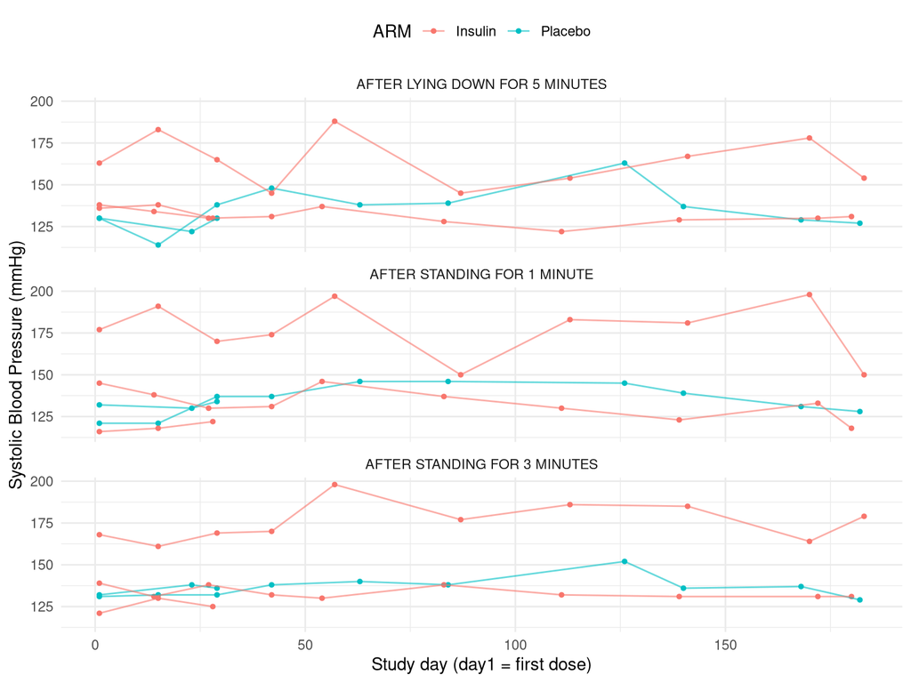

```r
advs_ana |>
  ggplot(aes(x = ADY, y = AVAL, group = USUBJID, colour = ARM)) +
  geom_point(size = 1) +
  geom_line(alpha = 0.6) +
  facet_wrap(~ATPT, ncol = 1) +
  labs(
    x = "Study day (day1 = first dose)",
    y = "Systolic Blood Pressure (mmHg)"
  ) +
    theme_minimal() +
    theme(legend.position = "top")
```

Only one patient stands out, bopping up and downfrom 150 to 200 mmHg at all measurements. The rest are pretty stable.

##### 4.4.2.2 Table

The classic table in a clinical study report: number of patients, mean value, and mean change from baseline, per treatment group and visit. I keep only the lying-down measurement (Easier to filter by`ATPTN == 815` than the text string “AFTER X…”) to keep it readable.

```r
sbp_summary <- advs_ana |>
  filter(ATPTN == 815) |>
  group_by(ARM, WEEK) |>
  summarise(
    n = n(),
    mean_sbp = mean(AVAL),
    mean_chg = mean(CHG),
    min_chg = min(CHG),
    max_chg = max(CHG),
    .groups = "drop"
  )

knitr::kable(sbp_summary, digits = 1)
```

| ARM | WEEK | n | mean_sbp | mean_chg | min_chg | max_chg |
| --- | --- | --- | --- | --- | --- | --- |
| Insulin | 0 | 3 | 145.7 | 0.0 | 0 | 0 |
| Insulin | 2 | 3 | 151.7 | 6.0 | -4 | 20 |
| Insulin | 4 | 3 | 141.7 | -4.0 | -8 | 2 |
| Insulin | 6 | 2 | 138.0 | -12.5 | -18 | -7 |
| Insulin | 8 | 2 | 162.5 | 12.0 | -1 | 25 |
| Insulin | 12 | 2 | 136.5 | -14.0 | -18 | -10 |
| Insulin | 16 | 2 | 138.0 | -12.5 | -16 | -9 |
| Insulin | 20 | 2 | 148.0 | -2.5 | -9 | 4 |
| Insulin | 24 | 2 | 154.0 | 3.5 | -8 | 15 |
| Insulin | 26 | 2 | 142.5 | -8.0 | -9 | -7 |
| Placebo | 0 | 2 | 130.0 | 0.0 | 0 | 0 |
| Placebo | 2 | 2 | 118.0 | -12.0 | -16 | -8 |
| Placebo | 4 | 2 | 134.0 | 4.0 | 0 | 8 |
| Placebo | 6 | 1 | 148.0 | 18.0 | 18 | 18 |
| Placebo | 8 | 1 | 138.0 | 8.0 | 8 | 8 |
| Placebo | 12 | 1 | 139.0 | 9.0 | 9 | 9 |
| Placebo | 16 | 1 | 163.0 | 33.0 | 33 | 33 |
| Placebo | 20 | 1 | 137.0 | 7.0 | 7 | 7 |
| Placebo | 24 | 1 | 129.0 | -1.0 | -1 | -1 |
| Placebo | 26 | 1 | 127.0 | -3.0 | -3 | -3 |

#### 4.4.3 Mean changes

Overlaying is possible here, with thick lines being the mean, and thin being individual patients.

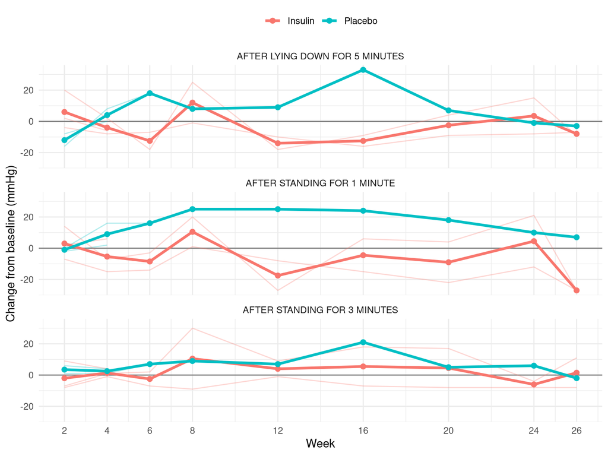

```r
advs_ana |>
  filter(WEEK > 0) |>
  ggplot(aes(x = WEEK, y = CHG, colour = ARM)) +
  geom_hline(yintercept = 0, colour = "grey50") +
  geom_line(aes(group = USUBJID), alpha = 0.3) +
  stat_summary(fun = mean, geom = "line", linewidth = 1.2) +
  stat_summary(fun = mean, geom = "point", size = 2) +
  facet_wrap(~ATPT, ncol = 1) +
  scale_x_continuous(breaks = c(2, 4, 6, 8, 12, 16, 20, 24, 26)) +
  labs(
    x = "Week",
    y = "Change from baseline (mmHg)",
    colour = NULL
  ) +
  theme_minimal() +
  theme(legend.position = "top")
```

Below 0 = mean reduction, above = mean increase, relative to before treatment.

Too few patients to say anything.

#### 4.4.4 Validation against ref

The `pharmaverseadam` package comes with a finished `advs_metabolic` built from the same SDTM data. If my dataset differs, either I have a bug, or we made different choices.

```r
advs_ref <- pharmaverseadam::advs_metabolic |>
  filter(PARAMCD == "SYSBP") |>
  select(USUBJID, ADT, ATPTN, AVAL_REF = AVAL, BASE_REF = BASE, CHG_REF = CHG)

compare <- advs_sbp |>
  full_join(advs_ref, by = c("USUBJID", "ADT", "ATPTN"))

compare |>
  summarise(
    rows_mine = sum(!is.na(AVAL)),
    rows_ref = sum(!is.na(AVAL_REF)),
    aval_diff = sum(AVAL != AVAL_REF, na.rm = TRUE),
    base_diff = sum(BASE != BASE_REF, na.rm = TRUE)
  )
```

```
# A tibble: 1 × 4
  rows_mine rows_ref aval_diff base_diff
      <int>    <int>     <int>     <int>
1       165      165         0       103
```

```r
# Look at the baseline day
compare |>
  filter(ADY == 1) |>
  select(USUBJID, ATPT, AVAL, BASE, BASE_REF)
```

```
# A tibble: 15 × 5
   USUBJID     ATPT                            AVAL  BASE BASE_REF
   <chr>       <chr>                          <dbl> <dbl>    <dbl>
 1 01-701-1015 AFTER LYING DOWN FOR 5 MINUTES   130   130      131
 2 01-701-1015 AFTER STANDING FOR 1 MINUTE      121   121      131
 3 01-701-1015 AFTER STANDING FOR 3 MINUTES     131   131      131
 4 01-701-1023 AFTER LYING DOWN FOR 5 MINUTES   130   130      132
 5 01-701-1023 AFTER STANDING FOR 1 MINUTE      132   132      132
 6 01-701-1023 AFTER STANDING FOR 3 MINUTES     132   132      132
 7 01-701-1028 AFTER LYING DOWN FOR 5 MINUTES   138   138      139
 8 01-701-1028 AFTER STANDING FOR 1 MINUTE      145   145      139
 9 01-701-1028 AFTER STANDING FOR 3 MINUTES     139   139      139
10 01-701-1033 AFTER LYING DOWN FOR 5 MINUTES   136   136      121
11 01-701-1033 AFTER STANDING FOR 1 MINUTE      116   116      121
12 01-701-1033 AFTER STANDING FOR 3 MINUTES     121   121      121
13 01-701-1034 AFTER LYING DOWN FOR 5 MINUTES   163   163      168
14 01-701-1034 AFTER STANDING FOR 1 MINUTE      177   177      168
15 01-701-1034 AFTER STANDING FOR 3 MINUTES     168   168      168
```

All 165 rows match, and every blood pressure value (`AVAL`) is identical. But `BASE` differs in 103 rows. The choice of baseline explains it. They used “AFTER STANDING FOR 3 MINUTES” as the only baseline.

So there is a difference due to a different choice being made.

## 5 Closing thoughts

This was a wonderful learning experience.

I spent much time trying to understand the syntax of the `admiral` package, but I love learning, and the package totally makes sense and is obviously made by people who know a great deal about how R can be used to make ADaM datasets.

Didn’t know much about the `expr()` function, but have definitely used it indirectly before, through some `tidyverse` function that contains it.

Next, I shall look further into a dataset with more patients, such that I can create a whole set of “meaningful” Tables, Listings, and Figures.

## 6 Refactor

I have decided to drop the refactor section of my posts. Anyone who would want to use the code I make, could simply paste the entire post into an LLM and it will refactor it for them.

**Refactoring “by hand” is still a valuable tool to learn how things work, so I will instead do it as part of writing the post**.

The learning is still happening, there is just no need to paste the end result of that learning.